# RNotes - RSQL

Dr. Shoemaker

DATA 2401

```r
#install.packages("dbplyr") ## run once per machine
library(DBI) ## in every relevant script
library(dplyr)  ## in every relevant script
library(dbplyr)  ## in every relevant script

#### for a SQLite database
#install.packages("RSQLite") ## once per machine
library(RSQLite) ## in every relevant script

### for a postgres database
#install.packages("RPostgreSQL")  ## once per machine
# library(RPostgreSQL) ## in every relevant script
```

# Create a connection to the database

```r
db_connection <- dbConnect(SQLite(), dbname = "Chinook_Sqlite.sqlite")
```

In your environment, there is now something there of the class “SQLiteConnection”!

Dont forget to disconnect at the end of the script!

```r
dbDisconnect(db_connection)
```

# Work with the database

So, let’s work with the Database.

```r
# reconnect
db_connection <- dbConnect(SQLite(), dbname = "Chinook_Sqlite.sqlite") # reconnect
```

The function dbListTables() gives a …. list of the tables. shocking.

```r
dbListTables(db_connection)
```

```
##  [1] "Album"         "Artist"        "Customer"      "Employee"
##  [5] "Genre"         "Invoice"       "InvoiceLine"   "MediaType"
##  [9] "Playlist"      "PlaylistTrack" "Track"
```

To reference a table, we need to create a *reference* to the table as a variable. This uses the function `tbl`.

Do this for the table named “Artist”:

```r
## give the connection to the database, then the name of the table you want AS A STRING
Artist_table <- tbl(db_connection,'Artist')

## print out the table reference
print(Artist_table)
```

```
## # A query:  ?? x 2
## # Database: sqlite 3.53.3 [/Users/katherineshoemaker/Library/CloudStorage/OneDrive-UniversityofHoustonDowntown/0_Teaching/Courses/DATA2401/Fall2026/d19/Chinook_Sqlite.sqlite]
##    ArtistId Name
##       <int> <chr>
##  1        1 AC/DC
##  2        2 Accept
##  3        3 Aerosmith
##  4        4 Alanis Morissette
##  5        5 Alice In Chains
##  6        6 Antônio Carlos Jobim
##  7        7 Apocalyptica
##  8        8 Audioslave
##  9        9 BackBeat
## 10       10 Billy Cobham
## # ℹ more rows
```

Let’s do the same for the album table, and query just the Alanis Morissette albums

```r
## reference the "album" table
Album_table <- tbl(db_connection, "Album")
Album_table
```

```
## # A query:  ?? x 3
## # Database: sqlite 3.53.3 [/Users/katherineshoemaker/Library/CloudStorage/OneDrive-UniversityofHoustonDowntown/0_Teaching/Courses/DATA2401/Fall2026/d19/Chinook_Sqlite.sqlite]
##    AlbumId Title                                 ArtistId
##      <int> <chr>                                    <int>
##  1       1 For Those About To Rock We Salute You        1
##  2       2 Balls to the Wall                            2
##  3       3 Restless and Wild                            2
##  4       4 Let There Be Rock                            1
##  5       5 Big Ones                                     3
##  6       6 Jagged Little Pill                           4
##  7       7 Facelift                                     5
##  8       8 Warner 25 Anos                               6
##  9       9 Plays Metallica By Four Cellos               7
## 10      10 Audioslave                                   8
## # ℹ more rows
```

```r
## we could see in the artist table that her artist ID is 4, so we reference that using dplyr and filter! JUST like a dataframe

Album_table |> filter(ArtistId == 4)
```

```
## # A query:  ?? x 3
## # Database: sqlite 3.53.3 [/Users/katherineshoemaker/Library/CloudStorage/OneDrive-UniversityofHoustonDowntown/0_Teaching/Courses/DATA2401/Fall2026/d19/Chinook_Sqlite.sqlite]
##   AlbumId Title              ArtistId
##     <int> <chr>                 <int>
## 1       6 Jagged Little Pill        4
```

What’s going on here? - `dbplyr` is automatically translating what you’re asking into SQL!

You can see the SQL commands by using `show_query`

```r
# save the query as an object
AM_query <- Album_table |> filter(ArtistId == 4)

# pass that object to show_query()
show_query(AM_query)
```

```
## <SQL>
## SELECT *
## FROM `Album`
## WHERE (`ArtistId` = 4.0)
```

IMPORTANT: The object AM_query is NOT the data. It’s a “lazy evaluation” of the query. Querying the data is less computationally heavy then actually going to get it, so this lets you test out the statements you’re making before you do it “for real”

To actually get the data in a format you can use, use `collect()`

- this command tells R to actually go “collect” the data you’ve queried for, to actually do the query.

```r
## collect the data from our Alanis query
AM_query_df <- collect(AM_query)
```

## Exercises

1. Use `dplyr` on our databases to list, then count the number of Employees referenced in the database.

```r
Employ_table <- tbl(db_connection, "Employee")
Employ_table |> select(FirstName, LastName, everything())
```

```
## # A query:  ?? x 15
## # Database: sqlite 3.53.3 [/Users/katherineshoemaker/Library/CloudStorage/OneDrive-UniversityofHoustonDowntown/0_Teaching/Courses/DATA2401/Fall2026/d19/Chinook_Sqlite.sqlite]
##   FirstName LastName EmployeeId Title ReportsTo BirthDate HireDate Address City
##   <chr>     <chr>         <int> <chr>     <int> <chr>     <chr>    <chr>   <chr>
## 1 Andrew    Adams             1 Gene…        NA 1962-02-… 2002-08… 11120 … Edmo…
## 2 Nancy     Edwards           2 Sale…         1 1958-12-… 2002-05… 825 8 … Calg…
## 3 Jane      Peacock           3 Sale…         2 1973-08-… 2002-04… 1111 6… Calg…
## 4 Margaret  Park              4 Sale…         2 1947-09-… 2003-05… 683 10… Calg…
## 5 Steve     Johnson           5 Sale…         2 1965-03-… 2003-10… 7727B … Calg…
## 6 Michael   Mitchell          6 IT M…         1 1973-07-… 2003-10… 5827 B… Calg…
## 7 Robert    King              7 IT S…         6 1970-05-… 2004-01… 590 Co… Leth…
## 8 Laura     Callahan          8 IT S…         6 1968-01-… 2004-03… 923 7 … Leth…
## # ℹ 6 more variables: State <chr>, Country <chr>, PostalCode <chr>,
## #   Phone <chr>, Fax <chr>, Email <chr>
```

```r
Employ_table |> count()
```

```
## # A query:  ?? x 1
## # Database: sqlite 3.53.3 [/Users/katherineshoemaker/Library/CloudStorage/OneDrive-UniversityofHoustonDowntown/0_Teaching/Courses/DATA2401/Fall2026/d19/Chinook_Sqlite.sqlite]
##       n
##   <int>
## 1     8
```

```r
## don't *need* to collect().
```

2. Use `join` to add the artists to their respective albums.

```r
Album_artist_query <- Album_table |> left_join(Artist_table) |> select(Title, Name)
show_query(Album_artist_query)
```

```
## <SQL>
## SELECT `Title`, `Name`
## FROM `Album`
## LEFT JOIN `Artist`
##   ON (`Album`.`ArtistId` = `Artist`.`ArtistId`)
```

3. What 5 artists have the most tracks?

```r
Track_table <- tbl(db_connection, "Track")

Track_table |>
  left_join(Album_table) |>
  left_join(Artist_table, join_by(ArtistId)) |>
  group_by(Name.y) |>
  summarise(num_songs = n()) |>
  slice_max(num_songs, n = 5)
```

```
## # A query:  ?? x 2
## # Database: sqlite 3.53.3 [/Users/katherineshoemaker/Library/CloudStorage/OneDrive-UniversityofHoustonDowntown/0_Teaching/Courses/DATA2401/Fall2026/d19/Chinook_Sqlite.sqlite]
##   Name.y       num_songs
##   <chr>            <int>
## 1 Iron Maiden        213
## 2 U2                 135
## 3 Led Zeppelin       114
## 4 Metallica          112
## 5 Deep Purple         92
## 6 Lost                92
```

4. Which countries have the most total invoices ordered from highest to lowest? Plot the bar chart.

```r
dbListTables(db_connection) ## lists the tables
```

```
##  [1] "Album"         "Artist"        "Customer"      "Employee"
##  [5] "Genre"         "Invoice"       "InvoiceLine"   "MediaType"
##  [9] "Playlist"      "PlaylistTrack" "Track"
```

```r
dbListFields(db_connection, "Invoice") ## lists the columns in a specific table
```

```
## [1] "InvoiceId"         "CustomerId"        "InvoiceDate"
## [4] "BillingAddress"    "BillingCity"       "BillingState"
## [7] "BillingCountry"    "BillingPostalCode" "Total"
```

```r
Invoice_table <- tbl(db_connection, "Invoice")
Invoice_table |> count(BillingCountry) |> arrange(-n) ## results
```

```
## # A query:    ?? x 2
## # Database:   sqlite 3.53.3 [/Users/katherineshoemaker/Library/CloudStorage/OneDrive-UniversityofHoustonDowntown/0_Teaching/Courses/DATA2401/Fall2026/d19/Chinook_Sqlite.sqlite]
## # Ordered by: -n
##    BillingCountry     n
##    <chr>          <int>
##  1 USA               91
##  2 Canada            56
##  3 Brazil            35
##  4 France            35
##  5 Germany           28
##  6 United Kingdom    21
##  7 Czech Republic    14
##  8 Portugal          14
##  9 India             13
## 10 Argentina          7
## # ℹ more rows
```

```r
show_query(Invoice_table |> count(BillingCountry) |> arrange(-n)) ## showing the SQL to get there
```

```
## <SQL>
## SELECT `BillingCountry`, COUNT(*) AS `n`
## FROM `Invoice`
## GROUP BY `BillingCountry`
## ORDER BY -`n`
```

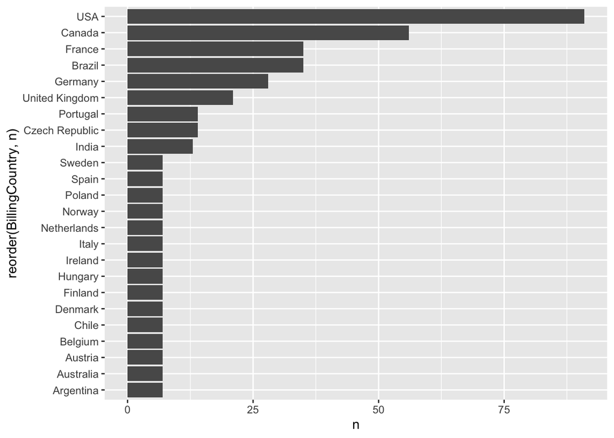

```r
library(tidyverse) # loading the library we need to plot
Invoice_table |>
  count(BillingCountry) |>
  arrange(-n) |>
  ggplot(aes(y = reorder(BillingCountry, n), x = n)) + geom_col()
```

5. Who is the top-spending customer overall, and what is their total purchase amount?

```r
dbListFields(db_connection, "Invoice") ## lists the columns in a specific table
```

```
## [1] "InvoiceId"         "CustomerId"        "InvoiceDate"
## [4] "BillingAddress"    "BillingCity"       "BillingState"
## [7] "BillingCountry"    "BillingPostalCode" "Total"
```

```r
dbListFields(db_connection, "Customer")
```

```
##  [1] "CustomerId"   "FirstName"    "LastName"     "Company"      "Address"
##  [6] "City"         "State"        "Country"      "PostalCode"   "Phone"
## [11] "Fax"          "Email"        "SupportRepId"
```

```r
## just here to help/remind whats in the different tables


Customer_table <- tbl(db_connection, "Customer")

Invoice_table |>
  group_by(CustomerId) |>
  summarise(total_amount = sum(Total)) |>
  left_join(Customer_table, join_by(CustomerId)) |>
  arrange(-total_amount)
```

```
## # A query:    ?? x 14
## # Database:   sqlite 3.53.3 [/Users/katherineshoemaker/Library/CloudStorage/OneDrive-UniversityofHoustonDowntown/0_Teaching/Courses/DATA2401/Fall2026/d19/Chinook_Sqlite.sqlite]
## # Ordered by: -total_amount
##    CustomerId total_amount FirstName LastName   Company Address      City  State
##         <int>        <dbl> <chr>     <chr>      <chr>   <chr>        <chr> <chr>
##  1          6         49.6 Helena    Holý       <NA>    Rilská 3174… Prag… <NA>
##  2         26         47.6 Richard   Cunningham <NA>    2211 W Berr… Fort… TX
##  3         57         46.6 Luis      Rojas      <NA>    Calle Lira,… Sant… <NA>
##  4         45         45.6 Ladislav  Kovács     <NA>    Erzsébet kr… Buda… <NA>
##  5         46         45.6 Hugh      O'Reilly   <NA>    3 Chatham S… Dubl… Dubl…
##  6         24         43.6 Frank     Ralston    <NA>    162 E Super… Chic… IL
##  7         28         43.6 Julia     Barnett    <NA>    302 S 700 E  Salt… UT
##  8         37         43.6 Fynn      Zimmermann <NA>    Berger Stra… Fran… <NA>
##  9          7         42.6 Astrid    Gruber     <NA>    Rotenturmst… Vien… <NA>
## 10         25         42.6 Victor    Stevens    <NA>    319 N. Fran… Madi… WI
## # ℹ more rows
## # ℹ 6 more variables: Country <chr>, PostalCode <chr>, Phone <chr>, Fax <chr>,
## #   Email <chr>, SupportRepId <int>
```